# Exploratory Data Analysis

Wind Patterns & Air Pollution in Paris, France.

Léo Zabrocki https://lzabrocki.github.io/ (Paris School of Economics)https://www.parisschoolofeconomics.eu/fr/zabrocki-leo/ , Anna Alari https://scholar.google.com/citations?user=MiFY320AAAAJ&hl=fr (Sorbonne Université & INSERM)https://www.inserm.fr/ , Tarik Benmarnhia https://profiles.ucsd.edu/tarik.benmarhnia (UCSD & Scripps Institute)https://benmarhniaresearch.ucsd.edu/  
2021-11-02

In this document, we carry out an exploratory data analysis to understand the relationships of wind patterns with other variables:

- We first explore general patterns related to wind directions.
- We then check if covariates are balanced when we define treated days as units with North-East winds and control days as units where winds blow from other directions.

**Should you have any questions, need help to reproduce the analysis or find coding errors, please do not hesitate to contact me at leo.zabrocki@psemail.eu**

# Required Packages

To reproduce exactly the `script_eda.html` document, we first need to have installed:

- the [R](https://www.r-project.org/) programming language on your computer
- [RStudio](https://rstudio.com/), an integrated development environment for R, which will allow you to knit the `script_eda.Rmd` file and interact with the R code chunks
- the [R Markdown](https://rmarkdown.rstudio.com/) package
- and the [Distill](https://rstudio.github.io/distill/) package which provides the template of this document.

Once everything is set up, we have to load the following packages:

```r
# load required packages
library(knitr) # for creating the R Markdown document
library(here) # for files paths organization
library(tidyverse) # for data manipulation and visualization
library(ggridges) # for ridge plots
library(openair) # polar plots
```

We load our custom `ggplot2` theme for graphs:

```r
# load ggplot customed theme
source(here::here(
  "2.scripts",
  "4.custom_ggplot2_theme",
  "script_theme_tufte.R"
))
# define nice colors
my_blue <- "#0081a7"
my_orange <- "#fb8500"
```

We finally load the data:

```r
# load data
data <-
  readRDS(here::here("1.data", "5.data_for_analysis", "data_for_analysis.RDS"))
```

# General EDA

We explore general patterns related to wind directions.

### Wind Direction & Air Pollutants

We plot the distribution of PM10 concentration by wind direction:

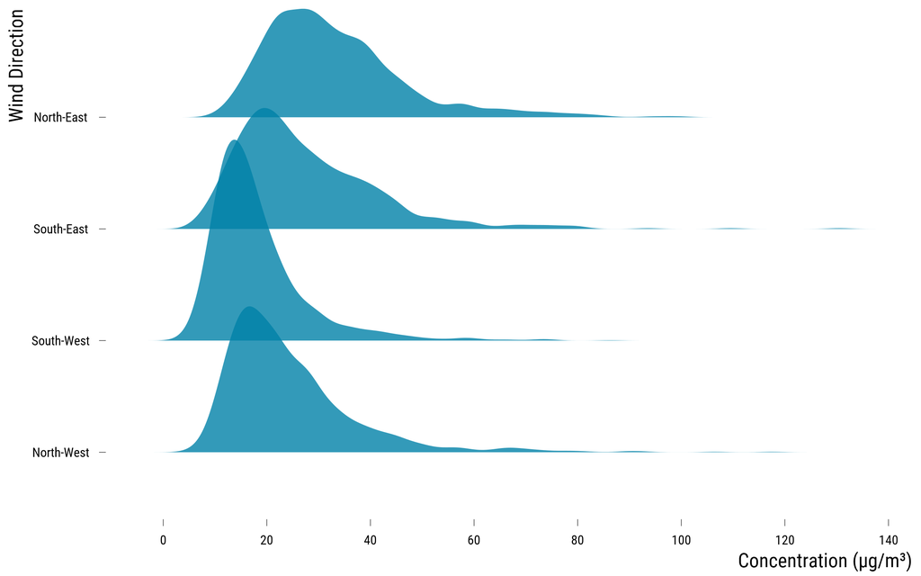

```r
# make the graph
graph_wd_pm10 <- data %>%
  ggplot(., aes(x = mean_pm10, y = fct_rev(wind_direction_categories))) +
  geom_density_ridges(
    color = NA,
    size = 0.3,
    fill = my_blue,
    alpha = 0.8
  ) +
  scale_x_continuous(breaks = scales::pretty_breaks(n = 8)) +
  xlab("Concentration (µg/m³)") +
  ylab("Wind Direction") +
  theme_tufte() +
  theme(axis.title.y = element_text(angle = 90, hjust = 1))

# display the graph
graph_wd_pm10
```

```r
# save the graph
ggsave(
  graph_wd_pm10,
  filename = here::here("3.outputs", "1.eda", "graph_wd_pm10.pdf"),
  width = 15,
  height = 8,
  units = "cm",
  device = cairo_pdf
)
```

We plot the distribution of all pollutant concentrations by wind direction:

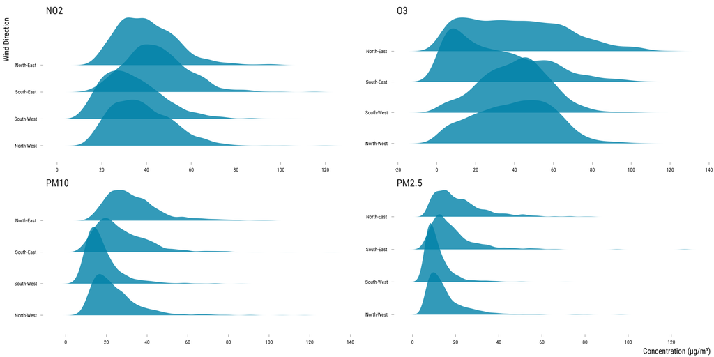

```r
# make the graph
graph_wd_pollutants <- data %>%
  rename(
    "PM10" = mean_pm10,
    "PM2.5" = mean_pm25,
    "NO2" = mean_no2,
    "O3" = mean_o3
  ) %>%
  pivot_longer(
    cols = c(PM10, PM2.5, NO2, O3),
    names_to = "pollutant",
    values_to = "concentration"
  ) %>%
  ggplot(.,  aes(x = concentration, y = fct_rev(wind_direction_categories))) +
  geom_density_ridges(
    color = NA,
    size = 0.3,
    fill = my_blue,
    alpha = 0.8
  ) +
  scale_x_continuous(breaks = scales::pretty_breaks(n = 8)) +
  facet_wrap( ~ pollutant, scales = "free") +
  xlab("Concentration (µg/m³)") +
  ylab("Wind Direction") +
  theme_tufte()

# display the graph
graph_wd_pollutants
```

```r
# save the graph
ggsave(
  graph_wd_pollutants,
  filename = here::here("3.outputs", "1.eda", "graph_wd_pollutants.pdf"),
  width = 20,
  height = 12,
  units = "cm",
  device = cairo_pdf
)
```

Using the `openair` package, we predict air pollutant concentrations using wind components:

```r
# select relevant variables for the polar plots
data_polar_plots <- data %>%
  select(wind_speed,
         wind_direction,
         mean_no2,
         mean_o3,
         mean_pm10,
         mean_pm25) %>%
  rename('Wind Speed' = wind_speed)

# make the polarPlot for all pollutants
no2_plot <-
  polarPlot(
    data_polar_plots,
    pollutant = "mean_no2",
    x = "Wind Speed",
    wd = "wind_direction",
    main = "Average NO2 (' * mu * 'g/m' ^3 *')",
    key.header = "",
    key.footer = "",
    resolution = "fine",
    par.settings = list(fontsize = list(text = 18))
  )

o3_plot <-
  polarPlot(
    data_polar_plots,
    pollutant = "mean_o3",
    x = "Wind Speed",
    wd = "wind_direction",
    main = "Average O3 (' * mu * 'g/m' ^3 *')",
    key.header = "",
    key.footer = "",
    resolution = "fine",
    par.settings = list(fontsize = list(text = 18))
  )

pm10_plot <-
  polarPlot(
    data_polar_plots,
    pollutant = "mean_pm10",
    x = "Wind Speed",
    wd = "wind_direction",
    main = "Average PM10 (' * mu * 'g/m' ^3 *')",
    key.header = "",
    key.footer = "",
    resolution = "fine",
    par.settings = list(fontsize = list(text = 18))
  )

pm25_plot <-
  polarPlot(
    data_polar_plots,
    pollutant = "mean_pm25",
    x = "Wind Speed",
    wd = "wind_direction",
    main = "Average PM2.5 (' * mu * 'g/m' ^3 *')",
    key.header = "",
    key.footer = "",
    resolution = "fine",
    par.settings = list(fontsize = list(text = 18))
  )

# save the graph
pdf(
  here::here("3.outputs", "1.eda", "graph_polar_plots_pollutants.pdf"),
  width = 15,
  height = 5
)
print(no2_plot, split = c(1, 1, 4, 1), more = TRUE)
print(o3_plot, split = c(2, 1, 4, 1), more = TRUE)
print(pm10_plot, split = c(3, 1, 4, 1), more = TRUE)
print(pm25_plot, split = c(4, 1, 4, 1), more = FALSE)
dev.off()
```

### Wind Direction & Other Weather Parameters

We plot the distribution of continuous weather parameter by wind direction:

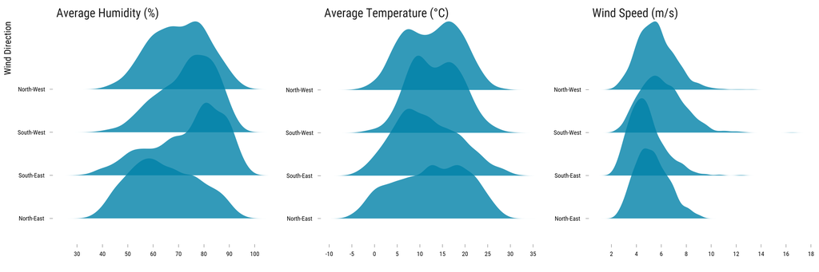

```r
# make the graph
graph_wd_weather <- data %>%
  rename(
    "Average Temperature (°C)" = temperature_average,
    "Average Humidity (%)" = humidity_average,
    "Wind Speed (m/s)" = wind_speed
  ) %>%
  pivot_longer(
    cols = c(
      "Average Temperature (°C)",
      "Average Humidity (%)",
      "Wind Speed (m/s)"
    ),
    names_to = "weather_parameter",
    values_to = "value"
  ) %>%
  mutate(
    horizontal_lines = case_when(
      weather_parameter == "Average Temperature (°C)" ~ -6,
      weather_parameter == "Average Humidity (%)" ~ 25,
      weather_parameter == "Wind Speed (m/s)" ~ 0
    )
  ) %>%
  ggplot(., aes(x = value, y = wind_direction_categories)) +
  geom_density_ridges(
    color = NA,
    size = 0.3,
    fill = my_blue,
    alpha = 0.8
  ) +
  scale_x_continuous(breaks = scales::pretty_breaks(n = 8)) +
  facet_wrap(~ weather_parameter, scales = "free") +
  xlab("") +
  ylab("Wind Direction") +
  theme_tufte()

# display the graph
graph_wd_weather
```

```r
# save the graph
ggsave(
  graph_wd_weather,
  filename = here::here("3.outputs", "1.eda", "graph_wd_weather.pdf"),
  width = 30,
  height = 10,
  units = "cm",
  device = cairo_pdf
)
```

We plot the distribution of rainfall duration by wind direction:

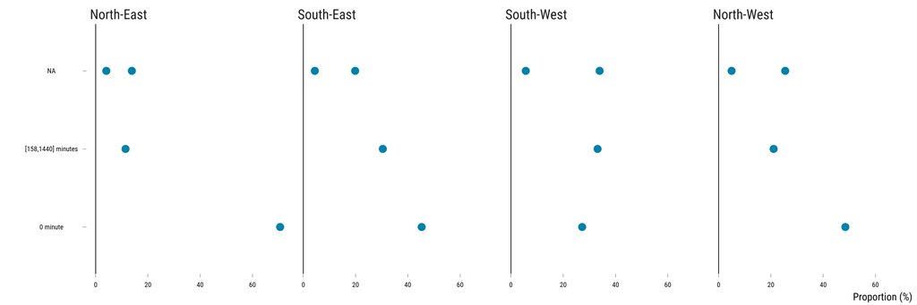

```r
# make the graph
graph_wd_rainfall <- data %>%
  select(rainfall_duration, wind_direction_categories) %>%
  group_by(wind_direction_categories, rainfall_duration) %>%
  summarise(n = n()) %>%
  mutate(proportion = n / sum(n) * 100) %>%
  ungroup() %>%
  mutate(
    rainfall_duration = case_when(
      rainfall_duration == "  0" ~ "0 minute",
      rainfall_duration == "[  1,  14)" ~ "[1, 14) minutes",
      rainfall_duration == "[ 14, 158)" ~ "[14, 158) minutes",
      rainfall_duration == "[158,1440]" ~ "[158,1440] minutes"
    )
  ) %>%
  mutate(
    rainfall_duration = fct_relevel(
      rainfall_duration,
      "0 minute",
      "[1, 14) minutes",
      "[14, 158) minutes",
      "[158,1440] minutes"
    )
  ) %>%
  ggplot(., aes(x = proportion, y = rainfall_duration)) +
  geom_point(shape = 16,
             colour = my_blue,
             size = 4) +
  geom_vline(xintercept = 0,
             size = 0.3,
             colour = "black") +
  facet_wrap( ~ wind_direction_categories, ncol = 4) +
  xlab("Proportion (%)") + ylab("") +
  theme_tufte()

# display the graph
graph_wd_rainfall
```

```r
# save the graph
ggsave(
  graph_wd_rainfall,
  filename = here::here("3.outputs", "1.eda", "graph_wd_rainfall.pdf"),
  width = 25,
  height = 10,
  units = "cm",
  device = cairo_pdf
)
```

### Wind Direction & Calendar Indicators

We plot the distribution of wind direction by month:

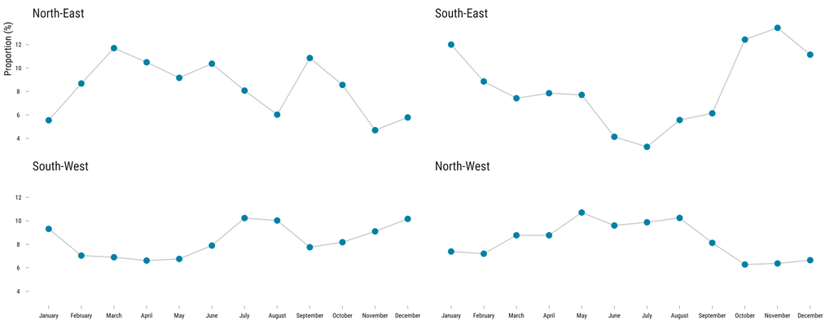

```r
# make the graph
graph_wd_month <- data %>%
  select(month, wind_direction_categories) %>%
  group_by(wind_direction_categories, month) %>%
  summarise(n = n()) %>%
  mutate(proportion = n / sum(n) * 100) %>%
  ungroup() %>%
  ggplot(., aes(x = month, y = proportion, group = "l")) +
  geom_line(colour = "gray80") +
  geom_point(colour = my_blue, size = 3) +
  scale_y_continuous(breaks = scales::pretty_breaks(n = 7)) +
  facet_wrap( ~ wind_direction_categories, ncol = 2) +
  xlab("") + ylab("Proportion (%)") +
  theme_tufte()
# display the graph
graph_wd_month
```

```r
# save the graph
ggsave(
  graph_wd_month,
  filename = here::here("3.outputs", "1.eda", "graph_wd_month.pdf"),
  width = 35,
  height = 15,
  units = "cm",
  device = cairo_pdf
)
```

We plot the distribution of wind direction by year:

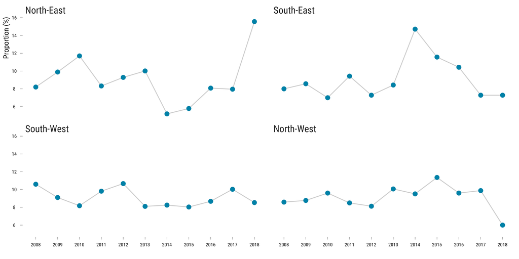

```r
# make the graph
graph_wd_year <- data %>%
  select(year, wind_direction_categories) %>%
  mutate(year = as.factor(year)) %>%
  group_by(wind_direction_categories, year) %>%
  summarise(n = n()) %>%
  mutate(proportion = n / sum(n) * 100) %>%
  ungroup() %>%
  ggplot(., aes(x = year, y = proportion, group = "l")) +
  geom_line(colour = "gray80") +
  geom_point(colour = my_blue, size = 3) +
  scale_y_continuous(breaks = scales::pretty_breaks(n = 7)) +
  facet_wrap( ~ wind_direction_categories, ncol = 2) +
  xlab("") + ylab("Proportion (%)") +
  theme_tufte()

# display the graph
graph_wd_year
```

```r
# save the graph
ggsave(
  graph_wd_year,
  filename = here::here("3.outputs", "1.eda", "graph_wd_year.pdf"),
  width = 30,
  height = 15,
  units = "cm",
  device = cairo_pdf
)
```

# Covariates Imbalance EDA

We check if covariates are balanced when we define treated days as units with North-East winds and control days as units where winds blow from other directions.

### Defining Treatment

The treatment is defined as follows:

- treated units are days where winds blow from the North-East in *t*.
- control units are day winds blow from other directions in *t*.

```r
# construct treatment assigment variable
data <- data %>%
  mutate(is_treated = ifelse(
    wind_direction_categories == "North-East",
    "Treated",
    "Control"
  ))
```

### Weather Covariates Imbalance

We plot density distributions for continuous weather covariates by treatment status:

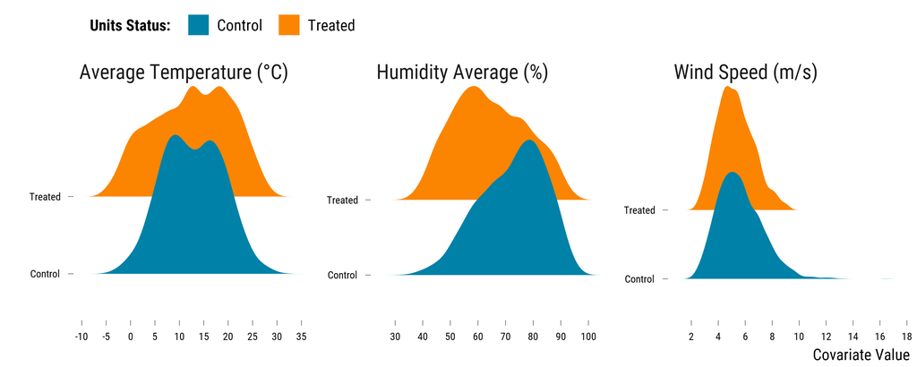

```r
# we select control variables and store them in a long dataframe
data_weather_continuous_variables <- data %>%
  select(temperature_average,
         humidity_average,
         wind_speed,
         is_treated) %>%
  pivot_longer(
    cols = -c(is_treated),
    names_to = "variable",
    values_to = "values"
  ) %>%
  mutate(
    variable = NA %>%
      ifelse(
        str_detect(variable, "temperature_average"),
        "Average Temperature (°C)",
        .
      ) %>%
      ifelse(
        str_detect(variable, "humidity_average"),
        "Humidity Average (%)",
        .
      ) %>%
      ifelse(str_detect(variable, "wind_speed"), "Wind Speed (m/s)", .)
  )

# make the graph
graph_boxplot_continuous_weather <-
  ggplot(data_weather_continuous_variables,
         aes(x = values, y = is_treated, fill = is_treated)) +
  geom_density_ridges(colour = NA) +
  scale_fill_manual(values = c(my_blue, my_orange)) +
  scale_x_continuous(breaks = scales::pretty_breaks(n = 10)) +
  xlab("Covariate Value") +
  ylab("") +
  labs(fill = "Units Status:") +
  facet_wrap( ~ variable, scale = "free", ncol = 3) +
  theme_tufte()

# we print the graph
graph_boxplot_continuous_weather
```

```r
# save the graph
ggsave(
  graph_boxplot_continuous_weather,
  filename = here::here("3.outputs", "1.eda", "graph_boxplot_continuous_weather.pdf"),
  width = 30,
  height = 10,
  units = "cm",
  device = cairo_pdf
)
```

We draw love plots which display the standardized mean differences between treated and control days for each weather covariate and by month:

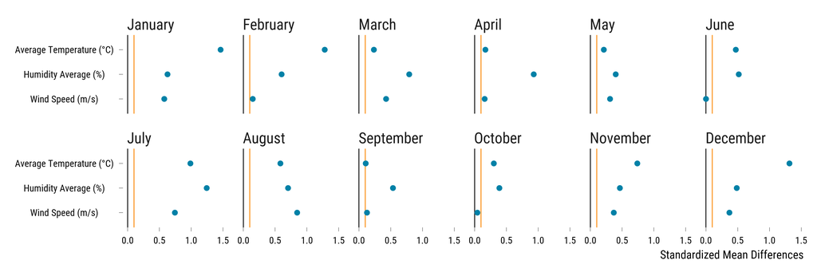

```r
# compute absolute differences
data_abs_difference <- data %>%
  select(month,
         is_treated,
         temperature_average,
         humidity_average,
         wind_speed) %>%
  group_by(month, is_treated) %>%
  summarise_all(., ~ mean(., na.rm = TRUE)) %>%
  pivot_longer(
    cols = -c(month, is_treated),
    names_to = "variable",
    values_to = "average"
  ) %>%
  arrange(month, variable) %>%
  group_by(month, variable) %>%
  summarise(abs_difference = abs(average[2] - average[1]))

# we compute the standard deviation of each treatment group covariate
data_sd <- data %>%
  select(month,
         is_treated,
         temperature_average,
         humidity_average,
         wind_speed) %>%
  filter(is_treated == "Treated") %>%
  select(-is_treated) %>%
  group_by(month) %>%
  summarise_all(., ~ sd(., na.rm = TRUE)) %>%
  pivot_longer(cols = -c(month),
               names_to = "variable",
               values_to = "sd_treatment")

# we merge data_abs_difference and data_sd
data_love <-
  left_join(data_abs_difference, data_sd, by = c("month", "variable")) %>%
  mutate(standardized_difference = abs_difference / sd_treatment) %>%
  select(-c(abs_difference, sd_treatment)) %>%
  mutate(
    variable = case_when(
      variable == "temperature_average" ~ "Average Temperature (°C)",
      variable == "humidity_average" ~ "Humidity Average (%)",
      variable == "wind_speed" ~ "Wind Speed (m/s)"
    )
  )

# we make the graph
graph_love <-
  ggplot(data_love, aes(y = fct_rev(variable), x = standardized_difference)) +
  geom_vline(xintercept = 0, size = 0.3) +
  geom_vline(xintercept = 0.1,
             color = my_orange,
             size = 0.3) +
  geom_point(size = 2, colour = my_blue) +
  facet_wrap( ~ month, ncol = 6) +
  xlab("Standardized Mean Differences") +
  ylab("") +
  theme_tufte() +
  theme(
    axis.text.y = element_text(size = 10),
    axis.text.x = element_text(size = 10),
    panel.spacing = unit(0.5, "cm"),
    plot.margin = unit(c(0.5, 0.5, 0.5, -0.5), "cm")
  )


# we print the graph
graph_love
```

```r
# save the graph
ggsave(
  graph_love,
  filename = here::here("3.outputs", "1.eda", "graph_love_weather.pdf"),
  width = 28,
  height = 9,
  units = "cm",
  device = cairo_pdf
)
```

### Calendar Imbalance

We plot the proportion of treated units by month:

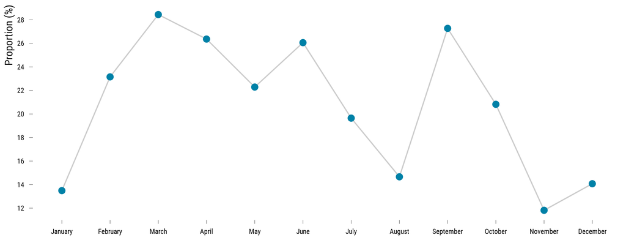

```r
# make the graph
graph_treated_month <- data %>%
  select(month, is_treated) %>%
  group_by(month, is_treated) %>%
  summarise(n = n()) %>%
  mutate(proportion = n / sum(n) * 100) %>%
  ungroup() %>%
  filter(is_treated == "Treated") %>%
  ggplot(., aes(x = month, y = proportion, group = "l")) +
  geom_line(colour = "gray80") +
  geom_point(colour = my_blue, size = 3) +
  scale_y_continuous(breaks = scales::pretty_breaks(n = 7)) +
  xlab("") + ylab("Proportion (%)") +
  theme_tufte()

# display the graph
graph_treated_month
```

```r
# save the graph
ggsave(
  graph_treated_month,
  filename = here::here("3.outputs", "1.eda", "graph_treated_month.pdf"),
  width = 20,
  height = 8,
  units = "cm",
  device = cairo_pdf
)
```